# Cionley Fisheries Simulation

Atul Sehgal

10-Sep-2022

## Load packages and create empty data frame

```r
# Load packages
library(tidyverse)

# Define n
n <- 500000

# Empty data frame for 1000 simulated days
data <- data.frame(day = seq(1:n),
                demand = NA, # demand in Rockport
                quantity = NA, # quantity sold
                price = NA, # price per pound
                cost = 10000, # cost of daily operations
                earnings = NA)

head(data)
```

```
##   day demand quantity price  cost earnings
## 1   1     NA       NA    NA 10000       NA
## 2   2     NA       NA    NA 10000       NA
## 3   3     NA       NA    NA 10000       NA
## 4   4     NA       NA    NA 10000       NA
## 5   5     NA       NA    NA 10000       NA
## 6   6     NA       NA    NA 10000       NA
```

Your goal in this project is to:

1. Fill in the dataset with random numbers drawn from the probability distributions defined in the case description—distributions for demand, quantity and price.
2. Use those numbers to compute earnings.
3. Summarize the earnings distribution to inform a business recommendation.

Note:

1. This case is slightly different from the one in the tutorial in that quantity sold is a function of demand: if demand is greater than 3500 then quantity is 3500 otherwise it equals demand. The mathematical notation used for this relationship in the case description—min(3500, D)—is NOT R code. There are various ways of creating the quantity variable but `ifelse()` works well.
2. Use set.seed(123) once before doing any simulation. Why 123? This is an arbitrary seed that controls a random process, making the results comparable. People who share the seed will get the same results. R will increment the seed in a deterministic fashion every time you run a random process. So if you simulate your random variables in a different order than the one stipulated in the empty dataframe that has been provided, you will get a different answer. Is it wrong? No, but your results will not be identical to those of your classmates. For example:

```r
set.seed(123)
rnorm(1000) %>% mean()
```

```
## [1] 0.01612787
```

```r
rnorm(1000) %>% mean()
```

```
## [1] 0.04246525
```

The means of the two samples are different (.016 vs. .042) because R has incremented the seed for the second sample.

Compare to:

```r
set.seed(123)
rnorm(1000) %>% mean()
```

```
## [1] 0.01612787
```

```r
set.seed(123)
rnorm(1000) %>% mean()
```

```
## [1] 0.01612787
```

3. Clint Conley has 50 boats, but we will be modeling earnings per boat. (It would be simple enough to multiply your per boat results by 50 to get earnings for the fleet.)

## Questions

Lightly comment your code and use pipes for readability.

Most of the questions require some writing. Please place your text immediately after the “>” in each question, which will make it into a block quote.

Use this code chunk to simulate demand, quantity and price, and then compute earnings. Make sure to use set.seed(123) before running any random process to ensure that your results are reproducible!

```r
set.seed(123)

sim <- data %>%
  mutate(demand=sample(x = c(0, 1000, 2000, 3000,4000,5000,6000),
                                 size = n,
                                 replace = T,
                                 prob = c(.02,.03, 0.05, 0.08,0.33,0.29,0.2)),
          quantity=if_else(demand>=3500,3500,demand),
          price=rnorm(n = n, mean = 3.65, sd = 0.2),
          earnings=price * quantity-10000
         )
```

### Q1

Plot simulated earnings.

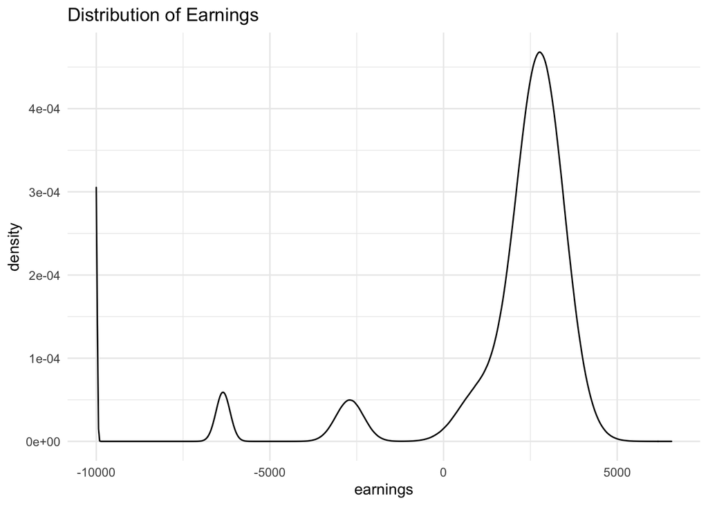

```r
ggplot(sim, aes(earnings)) +
  geom_density() +
  theme_minimal()+
  labs(title = "Distribution of Earnings")
```

### Q2

What is P(F > 1375)?

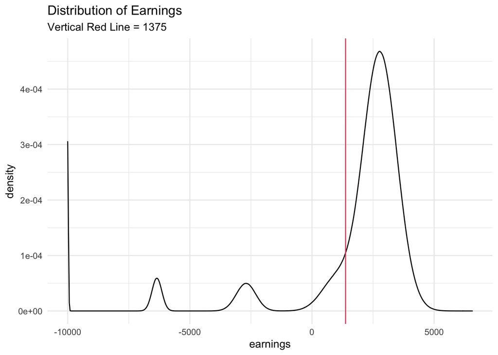

```r
ggplot(sim, aes(earnings)) +
  geom_density() +
  geom_vline(xintercept = 1375, col = 2) +
  theme_minimal()+
   labs(title = "Distribution of Earnings",
       subtitle = "Vertical Red Line = 1375")
```

```r
(sim$earnings > 1375) %>%
  mean
```

```
## [1] 0.819212
```

### Q3

What is P(F < 0)

[figure not shown]

```r
ggplot(sim, aes(earnings)) +
  geom_density() +
  geom_vline(xintercept = 0, col = 2) +
  theme_minimal()+
  labs(title = "Distribution of Earnings",
       subtitle = "Vertical Red Line = 0")
```

```r
(sim$earnings < 0) %>%
  mean
```

```
## [1] 0.104826
```

### Q4

What is the expected value (mean) of F?

```r
sim$earnings %>%
  mean
```

```
## [1] 1822.435
```

### Challenge

This question is optional and not graded!

Clint Conley is worried about an economic recession. He thinks that a recession would impact prices more at Rockport than at Gloucester, which, as the larger and better established market, is probably less vulnerable to macroeconomic changes. How much would the probability distribution of price need to change at Rockport in order to change your advice about which port he should use?

> In order for me to change my advice, the probabaility distribution of price at rockport should change to an extent that Clint has less than 0.5 probablity of making earnings of more than $1,375. With some trial and error I was able to arrive at a probability ditribution of price that can bring down his earnings at Rockport to this level.The price in this case should have a normal distribution with the mean $3.3 and a standard deviation of $0.33.

```r
set.seed(123)

sim2 <- data %>%
  mutate(demand=sample(x = c(0, 1000, 2000, 3000,4000,5000,6000),
                                 size = n,
                                 replace = T,
                                 prob = c(.02,.03, 0.05, 0.08,0.33,0.29,0.2)),
          quantity=if_else(demand>=3500,3500,demand),
          price=rnorm(n = n, mean = 3.3, sd = 0.33),
          earnings=price * quantity-10000
         )


(sim2$earnings > 1375) %>%
  mean
```

```
## [1] 0.464112
```

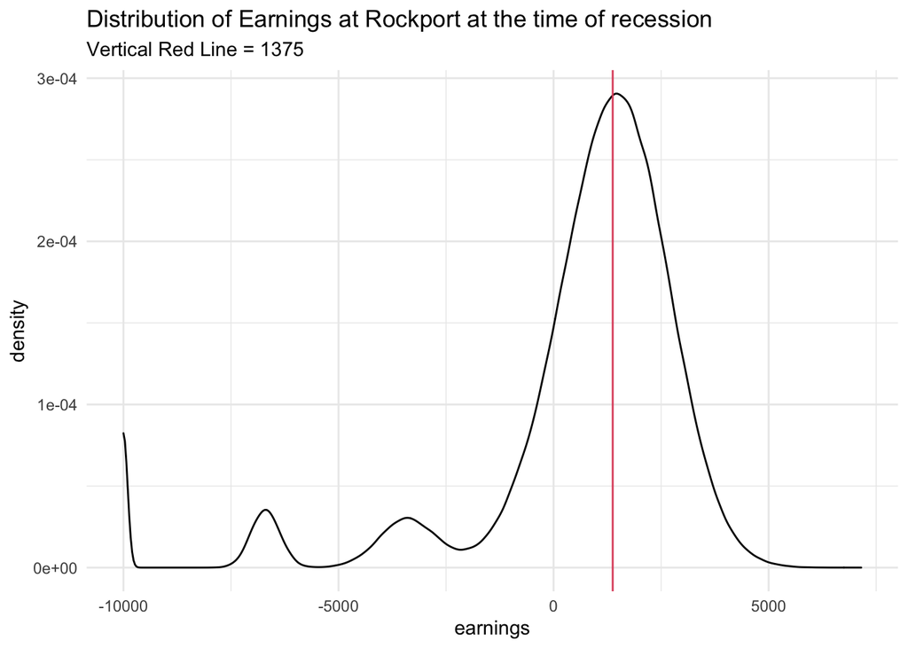

```r
ggplot(sim2, aes(earnings)) +
  geom_density() +
  geom_vline(xintercept = 1375, col = 2) +
  theme_minimal()+
  labs(title = "Distribution of Earnings at Rockport at the time of recession",
       subtitle = "Vertical Red Line = 1375")
```